# Hair Fall Risk Factors — Exploratory Data Analysis

Vicente Valero Just

2026-03-25

## Overview

This analysis explores the **Predict Hair Fall** dataset, which collects data on potential risk factors associated with hair loss. The goal is to understand the structure of the data, explore relationships between variables, and evaluate whether hair loss is driven by a single factor or by a combination of conditions.

## 1 — Dataset Loading and Initial Inspection

| Id | Genetics | Hormonal Changes | Medical Conditions | Medications & Treatments | Nutritional Deficiencies | Stress | Age | Poor Hair Care Habits | Environmental Factors | Smoking | Weight Loss | Hair Loss |
| --- | --- | --- | --- | --- | --- | --- | --- | --- | --- | --- | --- | --- |
| 133992 | Yes | No | No Data | No Data | Magnesium deficiency | Moderate | 19 | Yes | Yes | No | No | 0 |
| 148393 | No | No | Eczema | Antibiotics | Magnesium deficiency | High | 43 | Yes | Yes | No | No | 0 |
| 155074 | No | No | Dermatosis | Antifungal Cream | Protein deficiency | Moderate | 26 | Yes | Yes | No | Yes | 0 |
| 118261 | Yes | Yes | Ringworm | Antibiotics | Biotin Deficiency | Moderate | 46 | Yes | Yes | No | No | 0 |
| 111915 | No | No | Psoriasis | Accutane | Iron deficiency | Moderate | 30 | No | Yes | Yes | No | 1 |
| 139661 | Yes | No | Psoriasis | Antibiotics | Magnesium deficiency | Low | 37 | No | Yes | No | Yes | 1 |

### Dataset Structure

```
## Number of observations: 999
```

```
## Number of variables:    13
```

```
## Variable names:
```

```
##  [1] "Id"                       "Genetics"
##  [3] "Hormonal Changes"         "Medical Conditions"
##  [5] "Medications & Treatments" "Nutritional Deficiencies"
##  [7] "Stress"                   "Age"
##  [9] "Poor Hair Care Habits"    "Environmental Factors"
## [11] "Smoking"                  "Weight Loss"
## [13] "Hair Loss"
```

```
##
## Data types and structure:
```

```
## spc_tbl_ [999 × 13] (S3: spec_tbl_df/tbl_df/tbl/data.frame)
##  $ Id                      : num [1:999] 133992 148393 155074 118261 111915 ...
##  $ Genetics                : chr [1:999] "Yes" "No" "No" "Yes" ...
##  $ Hormonal Changes        : chr [1:999] "No" "No" "No" "Yes" ...
##  $ Medical Conditions      : chr [1:999] "No Data" "Eczema" "Dermatosis" "Ringworm" ...
##  $ Medications & Treatments: chr [1:999] "No Data" "Antibiotics" "Antifungal Cream" "Antibiotics" ...
##  $ Nutritional Deficiencies: chr [1:999] "Magnesium deficiency" "Magnesium deficiency" "Protein deficiency" "Biotin Deficiency" ...
##  $ Stress                  : chr [1:999] "Moderate" "High" "Moderate" "Moderate" ...
##  $ Age                     : num [1:999] 19 43 26 46 30 37 40 35 19 49 ...
##  $ Poor Hair Care Habits   : chr [1:999] "Yes" "Yes" "Yes" "Yes" ...
##  $ Environmental Factors   : chr [1:999] "Yes" "Yes" "Yes" "Yes" ...
##  $ Smoking                 : chr [1:999] "No" "No" "No" "No" ...
##  $ Weight Loss             : chr [1:999] "No" "No" "Yes" "No" ...
##  $ Hair Loss               : num [1:999] 0 0 0 0 1 1 1 0 1 0 ...
##  - attr(*, "spec")=
##   .. cols(
##   ..   Id = col_double(),
##   ..   Genetics = col_character(),
##   ..   `Hormonal Changes` = col_character(),
##   ..   `Medical Conditions` = col_character(),
##   ..   `Medications & Treatments` = col_character(),
##   ..   `Nutritional Deficiencies` = col_character(),
##   ..   Stress = col_character(),
##   ..   Age = col_double(),
##   ..   `Poor Hair Care Habits` = col_character(),
##   ..   `Environmental Factors` = col_character(),
##   ..   Smoking = col_character(),
##   ..   `Weight Loss` = col_character(),
##   ..   `Hair Loss` = col_double()
##   .. )
##  - attr(*, "problems")=<externalptr>
```

```
##
## Missing values per variable:
```

```
##                       Id                 Genetics         Hormonal Changes
##                        0                        0                        0
##       Medical Conditions Medications & Treatments Nutritional Deficiencies
##                        0                        0                        0
##                   Stress                      Age    Poor Hair Care Habits
##                        0                        0                        0
##    Environmental Factors                  Smoking              Weight Loss
##                        0                        0                        0
##                Hair Loss
##                        0
```

```
##
## Dataset size after cleaning: 999 13
```

```
##
## Statistical summary:
```

```
##        Id           Genetics         Hormonal Changes   Medical Conditions
##  Min.   :110003   Length:999         Length:999         Length:999
##  1st Qu.:131868   Class :character   Class :character   Class :character
##  Median :152951   Mode  :character   Mode  :character   Mode  :character
##  Mean   :153355
##  3rd Qu.:174969
##  Max.   :199949
##  Medications & Treatments Nutritional Deficiencies    Stress
##  Length:999               Length:999               Length:999
##  Class :character         Class :character         Class :character
##  Mode  :character         Mode  :character         Mode  :character
##
##
##
##       Age        Poor Hair Care Habits Environmental Factors   Smoking
##  Min.   :18.00   Length:999            Length:999            Length:999
##  1st Qu.:26.00   Class :character      Class :character      Class :character
##  Median :34.00   Mode  :character      Mode  :character      Mode  :character
##  Mean   :34.19
##  3rd Qu.:42.00
##  Max.   :50.00
##  Weight Loss          Hair Loss
##  Length:999         Min.   :0.0000
##  Class :character   1st Qu.:0.0000
##  Mode  :character   Median :0.0000
##                     Mean   :0.4975
##                     3rd Qu.:1.0000
##                     Max.   :1.0000
```

### Variable Overview

| Type | Variables |
| --- | --- |
| **Categorical** | Genetics, Hormonal Changes, Medical Conditions, Medications & Treatments, Nutritional Deficiencies, Stress, Poor Hair Care Habits, Environmental Factors, Smoking, Weight Loss |
| **Numerical** | Age, Hair Loss, Id |

**Potential analyses:**

- Frequency tables and bar charts for categorical variables
- Histograms and boxplots for numerical variables
- Chi-square tests for associations between categorical variables
- Correlation analysis between numerical variables
- t-test or ANOVA for group comparisons

## 2 — BOD Dataset Exploration

The built-in R dataset **BOD** (Biochemical Oxygen Demand) is used here to demonstrate dataset inspection and export workflows.

### 2.1 — Exploratory Summary

```
## BOD DATASET — BASIC INFORMATION
```

```
## Observations: 6
```

```
## Variables:    2
```

```
## Dimensions:   6 2
```

```
## Variable names:
```

```
## [1] "Time"   "demand"
```

```
##
## Data structure:
```

```
## 'data.frame':    6 obs. of  2 variables:
##  $ Time  : num  1 2 3 4 5 7
##  $ demand: num  8.3 10.3 19 16 15.6 19.8
##  - attr(*, "reference")= chr "A1.4, p. 270"
```

```
##
## Missing values:
```

```
##   Time demand
##      0      0
```

```
##
## Statistical summary:
```

```
##       Time           demand
##  Min.   :1.000   Min.   : 8.30
##  1st Qu.:2.250   1st Qu.:11.62
##  Median :3.500   Median :15.80
##  Mean   :3.667   Mean   :14.83
##  3rd Qu.:4.750   3rd Qu.:18.25
##  Max.   :7.000   Max.   :19.80
```

```
##
## Duplicated rows:
```

```
## [1] FALSE FALSE FALSE FALSE FALSE FALSE
```

The BOD dataset contains 6 observations and 2 numeric variables:

- **Time**: days elapsed
- **demand**: biochemical oxygen demand (mg/L)

No missing values or duplicates are present. Given its small size and temporal structure, this dataset is well-suited for scatter/line plots, linear or non-linear regression fitting, and organic matter degradation rate analysis.

### 2.2 — Exporting to Excel

```
## File exported to: C:/Users/Vincenzo Just/Desktop/Github/1/BOD_dataset.xlsx
```

```
## ✓ Export successful
```

## 3 — Stress, Nutritional Deficiencies, and Hair Loss

### 3.1 — Stress Level by Nutritional Deficiency

```
##
##            Biotin Deficiency Iron deficiency Magnesium deficiency No Data
##   High                  0.03            0.02                 0.02    0.03
##   Low                   0.04            0.02                 0.03    0.03
##   Moderate              0.03            0.03                 0.03    0.03
##
##            Omega-3 fatty acids Protein deficiency Selenium deficiency
##   High                    0.03               0.03                0.02
##   Low                     0.04               0.02                0.02
##   Moderate                0.03               0.04                0.04
##
##            Vitamin A Deficiency Vitamin D Deficiency Vitamin E deficiency
##   High                     0.03                 0.04                 0.03
##   Low                      0.04                 0.03                 0.03
##   Moderate                 0.03                 0.04                 0.02
##
##            Zinc Deficiency
##   High                0.04
##   Low                 0.04
##   Moderate            0.04
```

Key observations:

- **Low stress**: highest deficiencies in Biotin, Omega-3, and Vitamin A (≈ 0.04 each)
- **Moderate stress**: Protein, Selenium, and Vitamin D are most prevalent
- **High stress**: Vitamin D deficiency stands out
- **Zinc** shows a remarkably consistent pattern across all stress levels, suggesting its influence is independent of stress

### 3.2 — Stress Level and Hair Loss

```
## Contingency table — Hair Loss vs Stress:
```

```
##
##     High Low Moderate
##   0  165 168      169
##   1  156 159      182
```

```
##
## Proportions:
```

```
##
##     High  Low Moderate
##   0 0.17 0.17     0.17
##   1 0.16 0.16     0.18
```

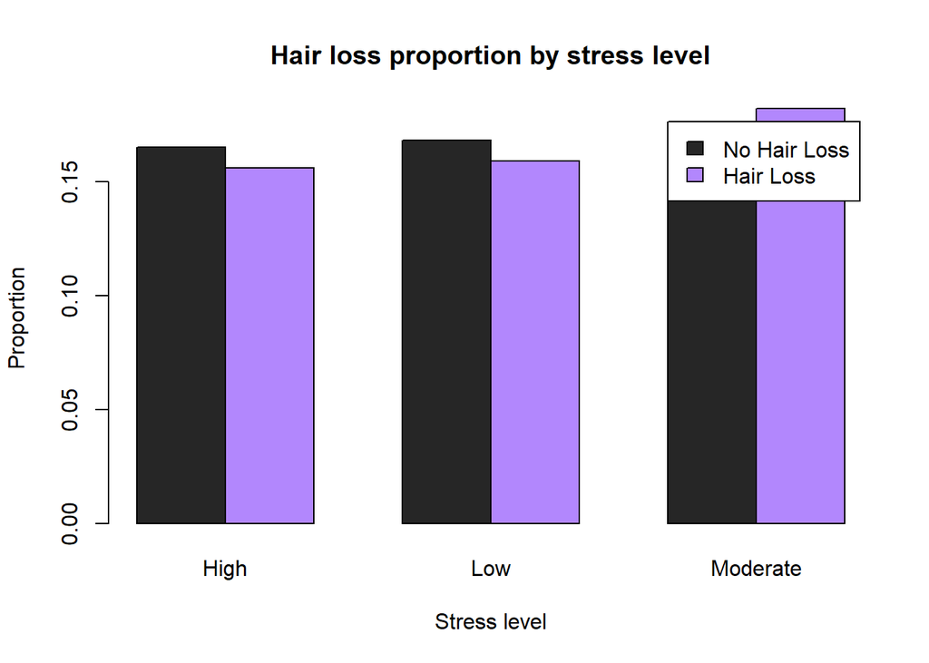

Proportions are broadly similar across stress levels, though individuals with **moderate stress** show a slightly higher incidence of hair loss. Stress appears to be a contributing — rather than determining — factor.

### 3.3 — Nutritional Deficiency and Hair Loss Count

```
## Number of individuals per nutritional deficiency:
```

```
##
##    Biotin Deficiency      Iron deficiency Magnesium deficiency
##                   99                   78                   84
##              No Data  Omega-3 fatty acids   Protein deficiency
##                   80                   92                   90
##  Selenium deficiency Vitamin A Deficiency Vitamin D Deficiency
##                   82                   99                  104
## Vitamin E deficiency      Zinc Deficiency
##                   83                  108
```

```
##
## Hair loss proportion by nutritional deficiency:
```

```
##
##                            0     1
##   Biotin Deficiency    0.535 0.465
##   Iron deficiency      0.487 0.513
##   Magnesium deficiency 0.452 0.548
##   No Data              0.475 0.525
##   Omega-3 fatty acids  0.543 0.457
##   Protein deficiency   0.478 0.522
##   Selenium deficiency  0.488 0.512
##   Vitamin A Deficiency 0.485 0.515
##   Vitamin D Deficiency 0.500 0.500
##   Vitamin E deficiency 0.542 0.458
##   Zinc Deficiency      0.528 0.472
```

```
##
## Proportion with hair loss per deficiency:
```

```
##    Biotin Deficiency      Iron deficiency Magnesium deficiency
##                0.465                0.513                0.548
##              No Data  Omega-3 fatty acids   Protein deficiency
##                0.525                0.457                0.522
##  Selenium deficiency Vitamin A Deficiency Vitamin D Deficiency
##                0.512                0.515                0.500
## Vitamin E deficiency      Zinc Deficiency
##                0.458                0.472
```

All deficiency types yield proportions between 0.45 and 0.55, with no single deficiency exceeding ~55% incidence. This strongly suggests that hair loss is **multifactorial** rather than tied to one specific nutritional deficit.

### 3.4 — Smokers Under the Age Mean with Hair Loss, by Stress Level

```
## Age mean: 34.18819
```

```
##
## Count by stress level:
```

```
##
##     High      Low Moderate
##       37       38       56
```

### 3.5 — Youngest Patients: High Stress, Smoking, Hair Loss, and Medication

```
## Nutritional deficiencies in this subgroup:
```

```
##
##  Omega-3 fatty acids Vitamin A Deficiency      Zinc Deficiency
##                    1                    1                    1
```

Three patients match this profile, each with a **different** nutritional deficiency — further confirming the multifactorial nature of hair loss observed in section 3.3.

### 3.6 — Hair Loss by Age Group and Stress Level

```
## Hair loss count by age group:
```

```
## age_group_hl
##   ≤20 21–30 31–40 41–50
##    45   148   175   129
```

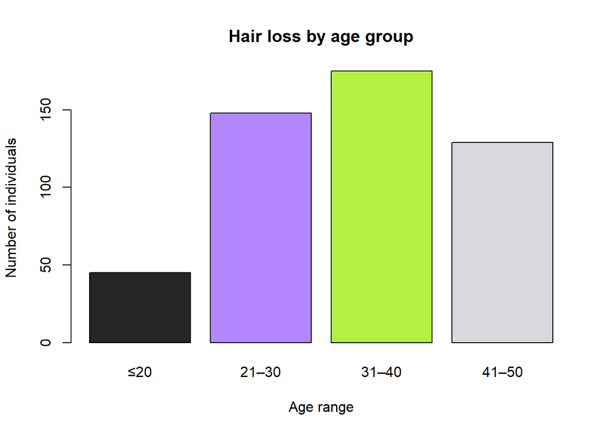

[output not shown]

```
##
## AgeGroup High Low Moderate
##    ≤20     27  28       31
##    21–30   99  95       97
##    31–40   90 116      116
##    41–50  105  88      107
```

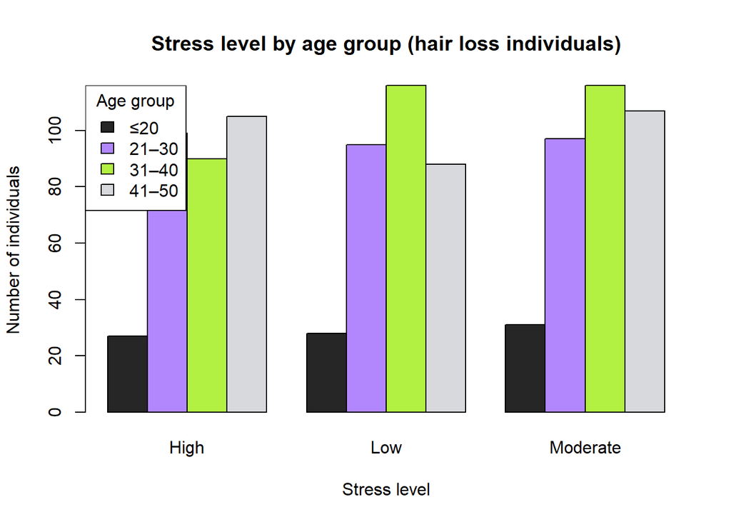

## 4 — Descriptive Statistics and Advanced Visualisations

### 4.1 — Descriptive Statistics

```
## DATASET STRUCTURE
```

```
## tibble [999 × 13] (S3: tbl_df/tbl/data.frame)
##  $ Id                      : num [1:999] 133992 148393 155074 118261 111915 ...
##  $ Genetics                : chr [1:999] "Yes" "No" "No" "Yes" ...
##  $ Hormonal Changes        : chr [1:999] "No" "No" "No" "Yes" ...
##  $ Medical Conditions      : chr [1:999] "No Data" "Eczema" "Dermatosis" "Ringworm" ...
##  $ Medications & Treatments: chr [1:999] "No Data" "Antibiotics" "Antifungal Cream" "Antibiotics" ...
##  $ Nutritional Deficiencies: chr [1:999] "Magnesium deficiency" "Magnesium deficiency" "Protein deficiency" "Biotin Deficiency" ...
##  $ Stress                  : chr [1:999] "Moderate" "High" "Moderate" "Moderate" ...
##  $ Age                     : num [1:999] 19 43 26 46 30 37 40 35 19 49 ...
##  $ Poor Hair Care Habits   : chr [1:999] "Yes" "Yes" "Yes" "Yes" ...
##  $ Environmental Factors   : chr [1:999] "Yes" "Yes" "Yes" "Yes" ...
##  $ Smoking                 : chr [1:999] "No" "No" "No" "No" ...
##  $ Weight Loss             : chr [1:999] "No" "No" "Yes" "No" ...
##  $ Hair Loss               : num [1:999] 0 0 0 0 1 1 1 0 1 0 ...
```

```
##
## Full summary:
```

```
##        Id           Genetics         Hormonal Changes   Medical Conditions
##  Min.   :110003   Length:999         Length:999         Length:999
##  1st Qu.:131868   Class :character   Class :character   Class :character
##  Median :152951   Mode  :character   Mode  :character   Mode  :character
##  Mean   :153355
##  3rd Qu.:174969
##  Max.   :199949
##  Medications & Treatments Nutritional Deficiencies    Stress
##  Length:999               Length:999               Length:999
##  Class :character         Class :character         Class :character
##  Mode  :character         Mode  :character         Mode  :character
##
##
##
##       Age        Poor Hair Care Habits Environmental Factors   Smoking
##  Min.   :18.00   Length:999            Length:999            Length:999
##  1st Qu.:26.00   Class :character      Class :character      Class :character
##  Median :34.00   Mode  :character      Mode  :character      Mode  :character
##  Mean   :34.19
##  3rd Qu.:42.00
##  Max.   :50.00
##  Weight Loss          Hair Loss
##  Length:999         Min.   :0.0000
##  Class :character   1st Qu.:0.0000
##  Mode  :character   Median :0.0000
##                     Mean   :0.4975
##                     3rd Qu.:1.0000
##                     Max.   :1.0000
```

```
##
## Numerical variables:
```

```
##        Id              Age
##  Min.   :110003   Min.   :18.00
##  1st Qu.:131868   1st Qu.:26.00
##  Median :152951   Median :34.00
##  Mean   :153355   Mean   :34.19
##  3rd Qu.:174969   3rd Qu.:42.00
##  Max.   :199949   Max.   :50.00
```

```
##
## ==== Genetics ====
##
##  No Yes
## 477 522
## Proportions (%): 47.7 52.3
##
## ==== Hormonal Changes ====
##
##  No Yes
## 490 509
## Proportions (%): 49 51
##
## ==== Medical Conditions ====
##
##       Alopecia Areata Androgenetic Alopecia            Dermatitis
##                   107                    98                    92
##            Dermatosis                Eczema               No Data
##                    88                    69                   110
##             Psoriasis              Ringworm       Scalp Infection
##                   100                    69                    79
## Seborrheic Dermatitis      Thyroid Problems
##                    88                    99
## Proportions (%): 10.7 9.8 9.2 8.8 6.9 11 10 6.9 7.9 8.8 9.9
##
## ==== Stress ====
##
##     High      Low Moderate
##      321      327      351
## Proportions (%): 32.1 32.7 35.1
##
## ==== Poor Hair Care Habits ====
##
##  No Yes
## 507 492
## Proportions (%): 50.8 49.2
##
## ==== Smoking ====
##
##  No Yes
## 480 519
## Proportions (%): 48 52
##
## ==== Weight Loss ====
##
##  No Yes
## 527 472
## Proportions (%): 52.8 47.2
##
## ==== Hair Loss ====
##
##   0   1
## 502 497
## Proportions (%): 50.3 49.7
```

**Variable roles:**

- **Age**: the only continuous variable; shows mean, median, range and distribution
- **Id**: row identifier — no analytical value
- **Hair Loss**: binary outcome variable (0 = no loss, 1 = loss)
- **Stress**: ordinal with 3 levels (Low / Moderate / High)
- **Medical Conditions, Genetics, Hormonal Changes…**: categorical risk factors

### 4.2 — Age Distribution by Hair Loss (Boxplot)

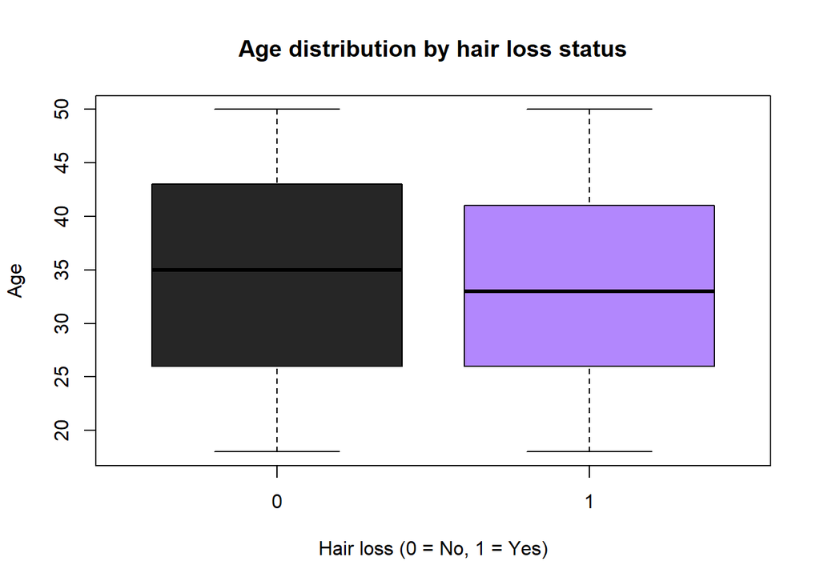

The age distributions for both groups are nearly identical, indicating that **age alone is not a determining factor** for hair loss. Its influence is likely amplified by other variables such as genetics, stress, medical conditions, and nutritional deficiencies — consistent with a multifactorial model.

### 4.3 — Medical Conditions and Hair Loss (Heat Map)

```
## Medical conditions vs hair loss (row proportions):
```

```
##
##                            0    1
##   Alopecia Areata       0.43 0.57
##   Androgenetic Alopecia 0.44 0.56
##   Dermatitis            0.52 0.48
##   Dermatosis            0.51 0.49
##   Eczema                0.52 0.48
##   No Data               0.57 0.43
##   Psoriasis             0.50 0.50
##   Ringworm              0.52 0.48
##   Scalp Infection       0.52 0.48
##   Seborrheic Dermatitis 0.43 0.57
##   Thyroid Problems      0.57 0.43
```

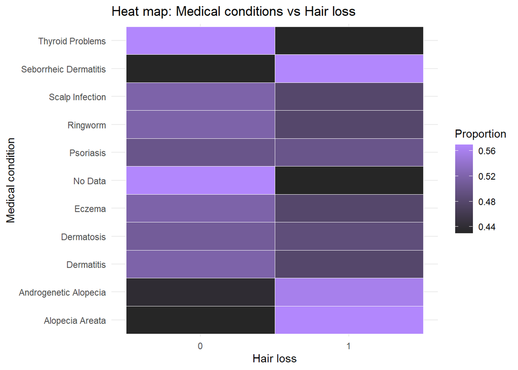

Among individuals **with hair loss (1)**, the most relevant medical conditions are:

- **Androgenetic Alopecia** and **Alopecia Areata** — expected, as they are defined by hair loss
- **Seborrheic Dermatitis** — consistent with known weakening of the hair shaft through excess sebum production

### 4.4 — Age Distribution of Hair Loss Individuals: Normality Assessment

```
## Sample size: 497
```

```
## Mean age: 33.5996
```

```
## Std dev:  9.128266
```

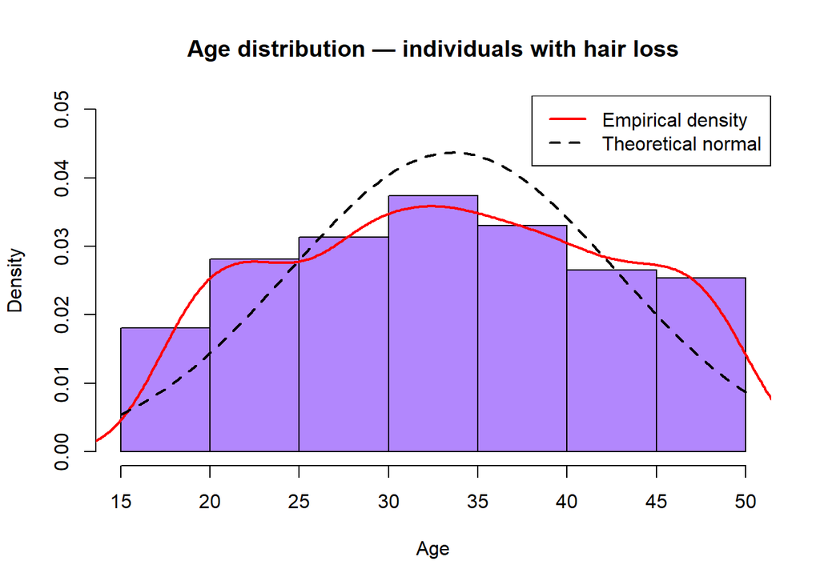

**Conclusion:** The age variable among hair loss individuals does **not** follow a normal distribution. This means subsequent statistical comparisons should use **non-parametric tests** rather than t-tests or ANOVA.